# eDNA

Richard Arnold

2024-07-16

## Detection of eDNA from tows

Model:

- $N$ organisms located at $(x,y,z)=(0,0,h)$
- shed $S$ copies per unit time
- plume moves at a constant velocity $v$ towards positive $x$ values
- disperse fully vertically after a short distance
- disperse by a random walk in the $y$ direction such that the dispersion in $y$ after time $t$ is $\sigma(t)=\sqrt{2A_Ht}$
- decay over time such that the number density at time $t$ is reduced by a factor of $e^{-\alpha t}$ after release at time $0$

Consider time $t$, following a time interval $\Delta t$ at $t=0$,

- $NS\Delta t$ copies are released at $t=0$
- the number density has decayed by a factor $e^{-\alpha t}$
- the plume has travelled distance $x=vt$
- the $NS\Delta t$ copies are dispersed over a distance $\Delta x=v\Delta t$ in $x$
- the copies are dispersed uniformly over the depth $h$
- the plume has dispersed in $y$ with dispersion $\sigma(x)=\sqrt{2A_Ht}=\sqrt{aA_Hx/v}$

Volume number density at location $(x,y,z)$ is
$$\begin{eqnarray*}
C(x,y,z)
&=& NS(\Delta t) \times e^{-\alpha t}
\times \frac{1}{\Delta x}
\times \frac{1}{\sqrt{2\pi\sigma^2(x)}}e^{-\frac12
y^2/\sigma^2(x)}
\times \frac{1}{h}\\
&=& \frac{NS}{hv}
\frac{1}{\sqrt{2\pi\sigma^2(x)}}e^{-\frac12 y^2/\sigma^2(x)-\alpha x/v}
\end{eqnarray*}$$

```r
xmax <- 15
ymax <- 10
np <- 101
Ah <- 1; v <- 2
xvec <- seq(from=0,to=xmax,length=np)
y1 <- 2*sqrt(2*Ah*xmax/v)
dx <- 1.5
dt <- dx/v
```

Consider a full depth tow at location $(x,y)$ with area $A_0$. The expected number of copies captured is
$$\begin{eqnarray*}
K_V(x,y) &=& \int\!\int_{A_{0}} {\rm d}x{\rm d}y \int_0^h {\rm
d}z\; C(x,y,z)\\
&=& A_0 C(x,y)\\
&=& \frac{NSA_0}{v}
\frac{1}{\sqrt{2\pi\sigma^2(x)}}e^{-\frac12 y^2/\sigma^2(x)-\alpha
x/v}\\
&=& \frac{NSV_V}{vh}
\frac{1}{\sqrt{2\pi\sigma^2(x)}}e^{-\frac12 y^2/\sigma^2(x)-\alpha x/v}
\end{eqnarray*}$$
where $C(x,y)=h C(x,y,z)$ is the area density (since $C(x,y,z)$ is independent of $z$), and $V_V=A_0h$ is the volume of water sampled.

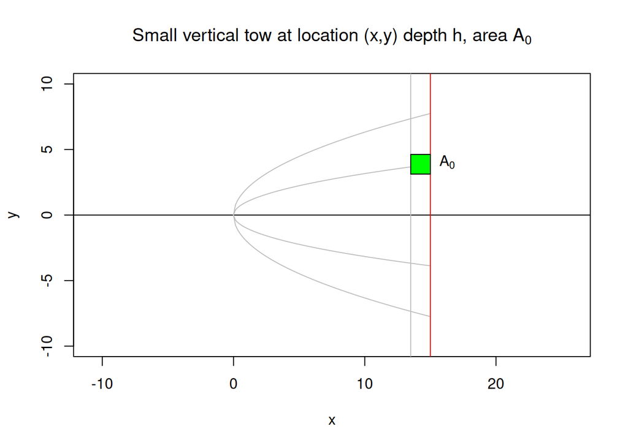

```r
plot(NA,NA,xlim=c(0,xmax),ylim=ymax*c(-1,1),xlab="x",ylab="y",asp=1)
abline(h=0)
lines(xvec, +sqrt(2*Ah*xvec/v),col="grey")
lines(xvec, -sqrt(2*Ah*xvec/v),col="grey")
lines(xvec, +2*sqrt(2*Ah*xvec/v),col="grey")
lines(xvec, -2*sqrt(2*Ah*xvec/v),col="grey")
abline(v=xmax,col="red")
abline(v=xmax-dx,col="grey")
text(xmax, y1/2, lab=expression(A[0]), pos=4)
polygon(xmax+c(-dx,0,0,-dx,-dx), (y1/2) + (dx/2)*c(-1,-1,1,1,-1), col="green")
title(expression("Small vertical tow at location (x,y) depth h, area "*A[0]))
```

Consider a full depth tow of length $L$ and width $w$ at constant $x$ across the plume, with $L$ being sufficiently large that the full plume is captured (i.e. $\frac12L>3\sigma(x)$. The expected number of copies captured is
$$\begin{eqnarray*}
K_H(x) &=& \int_{x-w/2}^{x+w/2} {\rm d}x \int_{-L/2}^{L/2}
{\rm d}y \int_0^h {\rm d}z\; C(x,y,z)\\
&=& w \frac{NS}{hv} e^{-\alpha x/v} h\\
&=& \frac{NSw}{v} e^{-\alpha x/v}\\
&=& \frac{NSV_H}{hLv} e^{-\alpha x/v}
\end{eqnarray*}$$
where $V_H=wLh$ is the volume of water sampled.

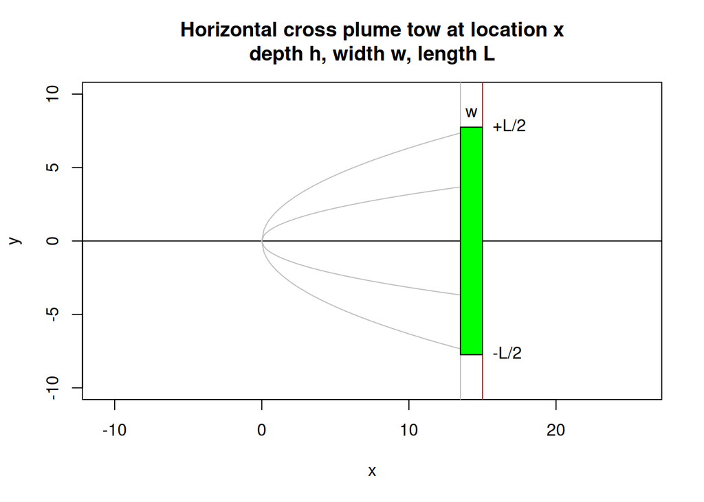

```r
plot(NA,NA,xlim=c(0,xmax),ylim=ymax*c(-1,1),xlab="x",ylab="y",asp=1)
abline(h=0)
lines(xvec, +sqrt(2*Ah*xvec/v),col="grey")
lines(xvec, -sqrt(2*Ah*xvec/v),col="grey")
lines(xvec, +2*sqrt(2*Ah*xvec/v),col="grey")
lines(xvec, -2*sqrt(2*Ah*xvec/v),col="grey")
abline(v=xmax,col="red")
abline(v=xmax-dx,col="grey")
text(xmax-dx/2, y1, lab="w", pos=3)
text(xmax, y1, lab="+L/2", pos=4)
text(xmax, -y1, lab="-L/2", pos=4)
polygon(xmax+c(-dx,0,0,-dx,-dx), y1*c(-1,-1,1,1,-1), col="green")
title("Horizontal cross plume tow at location x\ndepth h, width w, length L")
```

If $K$ is the expected number of copies captured, then the actual number of copies captured follows a Poisson distribution
$$Y|K \sim \text{Poisson}(K)$$
i.e.
$$\Pr(Y=y|K) = e^{-K} \frac{K^y}{y!}$$

Assume that the probability of detection ($Z=1$) given the presence of $y$ copies is $d(y)$, i.e.
$$\Pr(Z=1|y) = d(y)$$
then the probability of detection is
$$\begin{eqnarray*}
\Pr(Z=1) &=& \sum_{y=0}^\infty \Pr(Z=1|y) \Pr(Y=y)\\
&=& \sum_{y=0}^\infty d(y) e^{-K} \frac{K^y}{y!}
\end{eqnarray*}$$
If $d(y)$ is a simple threshold function $d(y)=I(y>y_t)$ (i.e. detection is certain above a threshold number $y_t$) then
$$\begin{eqnarray*}
\Pr(Z=1) &=& \sum_{y=y_t}^\infty e^{-K} \frac{K^y}{y!}\\
&=& 1 - \sum_{y=0}^{y_t-1} e^{-K} \frac{K^y}{y!}
\end{eqnarray*}$$

```r
knitr::knit_exit()
```